# Etapa 2 — Cargue y agregación de clima NASA POWER a cuadrante-semana

Análisis exploratorio de variables climáticas por cuadrante

Edwin Silva Salas

2026-09-17

# 1. Objetivo del análisis

El objetivo de esta sección es caracterizar la variabilidad temporal y espacial de las variables climatológicas agregadas semanalmente, con énfasis en:

- Identificar diferencias entre cuadrantes
- Detectar eventos extremos
- Evaluar correlaciones relevantes
- Generar insumos para la modelación predictiva

Unidad de muestreo: **cuadrantes por semana**.

# 2. Preparación de datos

```r
library(dplyr)
library(ggplot2)
library(tidyr)
library(lubridate)
library(readr)
library(readxl)
```

## Entorno (.env)

Se carga `UBICACION_DATA` desde el archivo `.env` — ninguna ruta queda fija en el código; cada persona del equipo apunta a su propia carpeta de datos.

```r
buscar_env <- function() {
  candidatos <- c(".env", file.path("..", ".env"), file.path("..", "..", ".env"),
                  file.path("..", "..", "..", ".env"), file.path("..", "..", "..", "..", ".env"))
  existentes <- candidatos[file.exists(candidatos)]
  if (length(existentes) == 0) return(NA_character_)
  existentes[1]
}
ruta_env <- buscar_env()
if (!is.na(ruta_env)) {
  readRenviron(ruta_env)
} else {
  warning("No se encontró un archivo .env. Copia .env.example como .env y ajusta UBICACION_DATA.")
}

UBICACION_DATA <- Sys.getenv("UBICACION_DATA")
if (UBICACION_DATA == "") {
  stop("UBICACION_DATA no esta definida. Verifica el archivo .env.")
}
cat(sprintf("UBICACION_DATA: %s\n", UBICACION_DATA))
```

```
## UBICACION_DATA: D:/OneDrive - PUJ Cali/Projecto_Grado_Javeriana/Data_Project/
```

# 3. Cargar y preparar datos base

## 3.1 Coordenadas de cuadrantes

```r
CUADRANTE_COORD <- read_excel(
  file.path(UBICACION_DATA, "Distribución de Cuadrantes", "CUADRANTE_CORD_800.xls")
) %>%
  rename(
    id_cuadrante = OBJECTID,
    longitud = POINT_X,
    latitud = POINT_Y
  )
```

## 3.2 Clima diario (NASA POWER consolidado)

```r
nasa_power_consolidado <- read_csv(
  file.path(UBICACION_DATA, "Distribución de Cuadrantes", "Output_Raw_API_NASA", "nasa_power_consolidado.csv")
)
```

## 3.3 Tabla de eventos

```r
tabla_eventos_ajustado <- read_csv(file.path(UBICACION_DATA, "tabla_eventos_ajustado.csv"))
head(tabla_eventos_ajustado)
```

```
## # A tibble: 6 × 6
##   ID_EVENTO FECHA_DESCONEXION FECHA_CONEXION   COMPONENTE_FALLADO
##       <dbl> <chr>             <chr>            <chr>
## 1    801851 14/03/2021 06:59  14/03/2021 09:30 PSW9292
## 2    787583 04/01/2021 08:50  04/01/2021 17:15 CMVE2356
## 3    787496 03/01/2021 14:18  03/01/2021 14:40 RC0158
## 4    787232 01/01/2021 10:29  01/01/2021 13:30 INSC92
## 5    787455 03/01/2021 10:34  03/01/2021 13:30 RC0259
## 6    787376 02/01/2021 12:09  02/01/2021 18:20 JMVE4672
## # ℹ 2 more variables: ELEMENTOS_AFECTADOS <dbl>, USUARIOS_AFECTADOS <dbl>
```

```r
tabla_eventos_ajustado_1 <- tabla_eventos_ajustado %>%
  mutate(
    FECHA_DESCONEXION = dmy_hm(FECHA_DESCONEXION),
    FECHA_CONEXION = dmy_hm(FECHA_CONEXION)
  )

tabla_eventos_ajustado_2 <- tabla_eventos_ajustado_1 %>%
  mutate(
    anio = year(FECHA_DESCONEXION),
    mes = floor_date(FECHA_DESCONEXION, "month"),
    semana = floor_date(FECHA_DESCONEXION, "week"),
    day = floor_date(FECHA_DESCONEXION, "day")
  )
```

# 4. Construcción de clima semanal

```r
clima_semana <- nasa_power_consolidado %>%
  mutate(
    semana = floor_date(fecha_consulta, "week", week_start = 1)
  ) %>%
  group_by(id_cuadrante, semana) %>%
  summarise(
    temp_media_semana = mean(temperatura_media_c, na.rm = TRUE),
    temp_max_semana = max(temperatura_maxima_c, na.rm = TRUE),
    temp_min_semana = min(temperatura_minima_c, na.rm = TRUE),

    precip_total_semana = sum(precipitacion_total_mm, na.rm = TRUE),

    humedad_media_semana = mean(humedad_relativa_pct, na.rm = TRUE),

    viento_medio_semana = mean(velocidad_viento_ms, na.rm = TRUE),
    viento_max_semana = max(velocidad_viento_ms, na.rm = TRUE),

    .groups = "drop"
  )
```

# 5. Variables de extremos

## 5.1 Principio técnico

No todas las variables climáticas se agregan igual:

| Variable | Agregación correcta | Justificación |
| --- | --- | --- |
| Precipitación | suma | es acumulativa |
| Temperatura media | promedio | nivel promedio de exposición |
| Temperatura máxima | máximo | eventos extremos |
| Temperatura mínima | mínimo | eventos extremos |
| Humedad | promedio | estado atmosférico |
| Viento | promedio + máximo (ideal) | nivel + ráfagas |

```r
clima_semana <- clima_semana %>%
  mutate(
    lluvia_intensa = as.integer(precip_total_semana > quantile(precip_total_semana, 0.9, na.rm = TRUE)),
    calor_extremo = as.integer(temp_max_semana > quantile(temp_max_semana, 0.9, na.rm = TRUE)),
    viento_fuerte = as.integer(viento_max_semana > quantile(viento_max_semana, 0.9, na.rm = TRUE))
  )
```

# 6. Incorporar coordenadas (panel espacial completo)

```r
clima_semana_spatial <- clima_semana %>%
  left_join(CUADRANTE_COORD, by = "id_cuadrante")
```

## Validación

```r
sum(is.na(clima_semana_spatial$latitud))
```

```
## [1] 0
```

## Exportación

Se exporta el resultado de esta etapa (`clima_semana_spatial`), que es el insumo que consume el siguiente documento del pipeline (`Etapa2_12_union_panel_semana.Rmd`) — ya no se guarda en una ruta fija de usuario, sino en `UBICACION_DATA`.

```r
saveRDS(clima_semana_spatial, file.path(UBICACION_DATA, "clima_semana_spatial.rds"))
cat(sprintf("clima_semana_spatial exportado: %d filas x %d columnas\n",
            nrow(clima_semana_spatial), ncol(clima_semana_spatial)))
```

```
## clima_semana_spatial exportado: 90128 filas x 14 columnas
```

# 7. EDA espacial

## 7.1 Promedios espaciales

```r
clima_mapa <- clima_semana_spatial %>%
  group_by(id_cuadrante, latitud, longitud) %>%
  summarise(
    precip_media = mean(precip_total_semana, na.rm = TRUE),
    temp_media = mean(temp_media_semana, na.rm = TRUE),
    viento_medio = mean(viento_medio_semana, na.rm = TRUE),
    .groups = "drop"
  )
```

## 7.2 Mapa precipitación

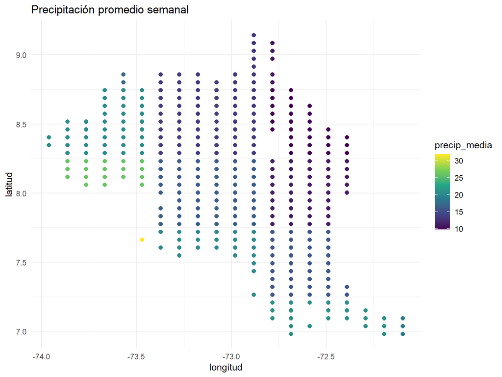

```r
ggplot(clima_mapa, aes(longitud, latitud)) +
  geom_point(aes(color = precip_media), size = 2) +
  scale_color_viridis_c() +
  theme_minimal() +
  labs(title = "Precipitación promedio semanal")
```

## 7.3 Mapa temperatura

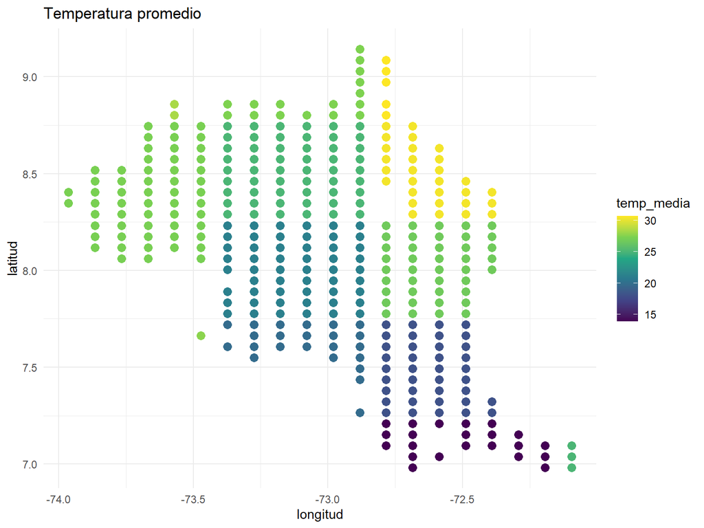

```r
ggplot(clima_mapa, aes(longitud, latitud)) +
  geom_point(aes(color = temp_media), size = 3) +
  scale_color_viridis_c() +
  theme_minimal() +
  labs(title = "Temperatura promedio")
```

## 7.4 Mapa viento

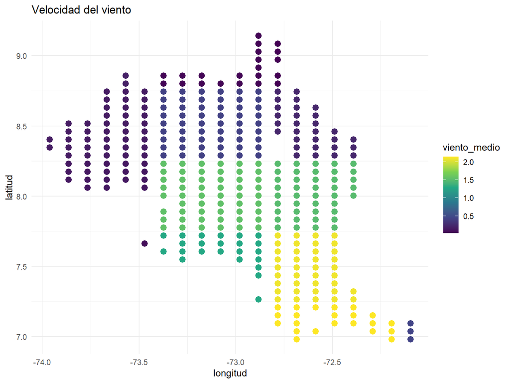

```r
ggplot(clima_mapa, aes(longitud, latitud)) +
  geom_point(aes(color = viento_medio), size = 3) +
  scale_color_viridis_c() +
  theme_minimal() +
  labs(title = "Velocidad del viento")
```

# 8. Dinámica temporal

```r
clima_tiempo <- clima_semana %>%
  group_by(semana) %>%
  summarise(
    temp_media = mean(temp_media_semana, na.rm = TRUE),
    temp_max = mean(temp_max_semana, na.rm = TRUE),
    temp_min = mean(temp_min_semana, na.rm = TRUE),

    precip = mean(precip_total_semana, na.rm = TRUE),

    humedad = mean(humedad_media_semana, na.rm = TRUE),

    viento_medio = mean(viento_medio_semana, na.rm = TRUE),
    viento_max = mean(viento_max_semana, na.rm = TRUE),

    .groups = "drop"
  )

# Pasar a formato largo
clima_tiempo_long <- clima_tiempo %>%
  pivot_longer(
    cols = -semana,
    names_to = "variable",
    values_to = "valor"
  ) %>%
  mutate(
    variable = recode(variable,
                      temp_media = "Temperatura media",
                      temp_max = "Temperatura máxima",
                      temp_min = "Temperatura mínima",
                      precip = "Precipitación",
                      humedad = "Humedad relativa",
                      viento_medio = "Viento medio",
                      viento_max = "Viento máximo"
    )
  )
```

## Indicadores de extremos a nivel temporal

Se agregan a nivel semanal (proporción de cuadrantes afectados cada semana):

```r
extremos_tiempo <- clima_semana %>%
  group_by(semana) %>%
  summarise(
    lluvia_extrema = mean(lluvia_intensa, na.rm = TRUE),
    viento_extremo = mean(viento_fuerte, na.rm = TRUE),
    .groups = "drop"
  )

# Unir con la serie temporal
clima_tiempo <- clima_tiempo %>%
  left_join(extremos_tiempo, by = "semana")
```

## Gráfico de dinámica temporal

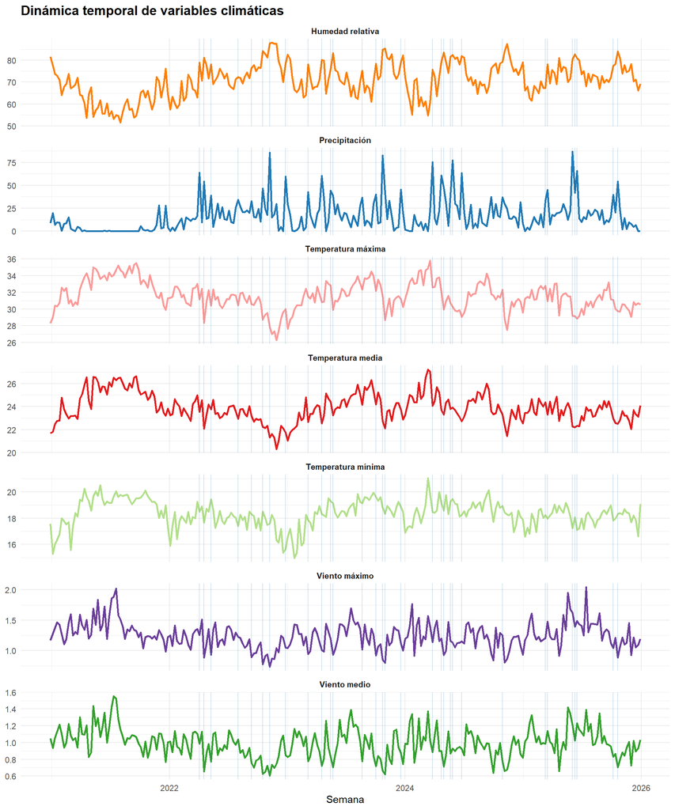

```r
ggplot(clima_tiempo_long, aes(x = semana, y = valor, color = variable)) +
  geom_line(linewidth = 1) +
  facet_wrap(~variable, scales = "free_y", ncol = 1) +
  scale_color_manual(values = c(
    "Temperatura media" = "#e31a1c",
    "Temperatura máxima" = "#fb9a99",
    "Temperatura mínima" = "#b2df8a",

    "Precipitación" = "#1f78b4",

    "Humedad relativa" = "#ff7f00",

    "Viento medio" = "#33a02c",
    "Viento máximo" = "#6a3d9a"
  )) +
  geom_vline(
    data = extremos_tiempo %>% filter(lluvia_extrema > 0.3),
    aes(xintercept = semana),
    color = "#1f78b4",
    alpha = 0.2
  ) +
  theme_minimal() +
  theme(
    legend.position = "none",
    strip.text = element_text(face = "bold"),
    plot.title = element_text(face = "bold", size = 14)
  ) +
  labs(
    title = "Dinámica temporal de variables climáticas",
    x = "Semana",
    y = NULL
  )
```